# Homework 3 Report

Classification of liver malfunction severity (LDA)

Ian Effendi \ iae2784@rit.edu

October 12, 2021

## Certification

> I certify that I indeed finished reading Ch. 4 from *An Introduction to Statistical Learning*, by James Gareth, Daniela Witten, Trevor Hastie, Robert Tibshirani.

## Overview

In this assignment we will:

- Perform exploratory data analysis (*EDA*) on the dataset.
- Fit and analyze a linear discriminant analysis (*LDA*) model on the dataset.
- Perform multiple cross-validation tasks at different $k$-fold values ($k=3,\,k=10$).

## ELT

*Much of the **extract**, **load**, and **transform** (**ELT**) process from the previous report has been revised for this assignment. Notably, a `make.dataset()` function streamlines the process of parsing the source `Liver.txt` file into a compatible `data.frame`.*

```r
# Import the dataset as variable called "Liver".
invisible(setup.analysis(target = "Liver"))
```

```
Use cached dataset? TRUE
'Liver' exists.
Importing dataset...
Parsing dataset from local file...
Reading dataset from compressed cache file...
Done.
Dataset imported.
Registered target dataset to global environment. Access using 'Liver'.
Use 'Liver' to access underlying tbl_df.
Dataset of type: 'tbl_df/tbl/data.frame'.
```

```
tibble [345 x 7] (S3: tbl_df/tbl/data.frame)
 $ blood.1 : int [1:345] 85 85 86 91 87 98 88 88 92 90 ...
 $ blood.2 : int [1:345] 92 64 54 78 70 55 62 67 54 60 ...
 $ blood.3 : int [1:345] 45 59 33 34 12 13 20 21 22 25 ...
 $ blood.4 : int [1:345] 27 32 16 24 28 17 17 11 20 19 ...
 $ blood.5 : int [1:345] 31 23 54 36 10 17 9 11 7 5 ...
 $ drinks  : num [1:345] 0 0 0 0 0 0 0.5 0.5 0.5 0.5 ...
 $ severity: Factor w/ 2 levels "Not Severe","Severe": 2 1 1 1 1 1 2 2 2 2 ...
```

The `setup.analysis()` function imports a dataset into the global environment with the name provided to the `target =` argument.

## EDA

*This section reviews the `Liver` dataset. In an improvement over the previous report, it now incorporates an assessment of feature correlations.*

### Response Encoding

```r
# Recode the response.
liver <- Liver %>% make.response()
summary(liver)
```

```
    blood.1          blood.2
 Min.   : 65.00   Min.   : 23.00
 1st Qu.: 87.00   1st Qu.: 57.00
 Median : 90.00   Median : 67.00
 Mean   : 90.16   Mean   : 69.87
 3rd Qu.: 93.00   3rd Qu.: 80.00
 Max.   :103.00   Max.   :138.00
    blood.3          blood.4
 Min.   :  4.00   Min.   : 5.00
 1st Qu.: 19.00   1st Qu.:19.00
 Median : 26.00   Median :23.00
 Mean   : 30.41   Mean   :24.64
 3rd Qu.: 34.00   3rd Qu.:27.00
 Max.   :155.00   Max.   :82.00
    blood.5           drinks
 Min.   :  5.00   Min.   : 0.000
 1st Qu.: 15.00   1st Qu.: 0.500
 Median : 25.00   Median : 3.000
 Mean   : 38.28   Mean   : 3.455
 3rd Qu.: 46.00   3rd Qu.: 6.000
 Max.   :297.00   Max.   :20.000
       severity
 Not Severe:200
 Severe    :145
```

### Feature Correlations

```r
liver.info <- analysis.eda(Liver, truth)
summary(liver.info)
```

```
 n_samples n_features
       345          7
Label counts:
  pos   neg total
  145   200   345
Class prior probabilities:
   pos    neg
0.4203 0.5797
```

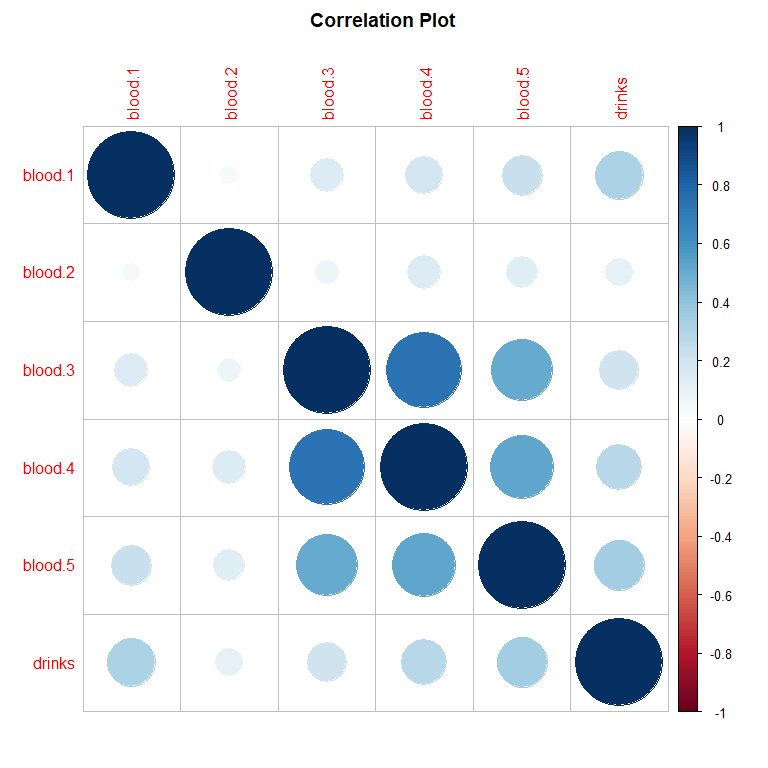

```r
# Plot using corrplot::corrplot wrapper.
liver.corrplot <- corr.plot(
  liver, sig.level = 0.05, insig = "blank",
  title = "Correlation Plot",
  mar = c(1,1,2,1)
)
```

The data behind the above correlation plot is provided below:

```
Feature correlation matrix:
        blood.1 blood.2 blood.3 blood.4
blood.1  1.0000 0.04410 0.14770  0.1878
blood.2  0.0441 1.00000 0.07621  0.1461
blood.3  0.1477 0.07621 1.00000  0.7397
blood.4  0.1878 0.14606 0.73967  1.0000
blood.5  0.2223 0.13314 0.50344  0.5276
drinks   0.3127 0.10080 0.20685  0.2796
        blood.5 drinks
blood.1  0.2223 0.3127
blood.2  0.1331 0.1008
blood.3  0.5034 0.2068
blood.4  0.5276 0.2796
blood.5  1.0000 0.3412
drinks   0.3412 1.0000
```

## Model Analysis

Models will be tracked using a named list `MODELS`:

```r
# Create a global `models` variable to keep track of models.
MODELS <<- list()
# Also, declares a reusable formula.
.FORMULA <<- severity ~ .
```

### Baseline Model Analysis

```r
# Fit LDA with priors calculated from the input sample.
# Equivalent to: MASS::lda(severity ~ ., data = liver)
# We use `.` instead of `baseline` for ease of typing.
MODELS$. <- fit.model(quote(liver), algorithm = lda, formula = .FORMULA)

# Temporary variable `model` for current analysed model:
model <- MODELS$.
```

```
Baseline LDA Summary:
Call:
lda(severity ~ ., data = liver)

Prior probabilities of groups:
Not Severe     Severe
    0.5797     0.4203

Group means:
           blood.1 blood.2 blood.3
Not Severe   89.81   68.34   29.82
Severe       90.63   71.98   31.21
           blood.4 blood.5 drinks
Not Severe   25.99   43.17  3.393
Severe       22.79   31.54  3.541

Coefficients of linear discriminants:
             LD1
blood.1  0.08312
blood.2  0.02263
blood.3  0.05893
blood.4 -0.11812
blood.5 -0.01497
drinks   0.06061
```

```
Baseline model error rate:
0.2957

Baseline misclassification table:

             Not Severe Severe
  Not Severe        165     67
  Severe             35     78

Total misclassified: 102
```

### Optimal Priors (for Total Error Rate)

We can calculate the model that minimizes the total error rate while explicitly setting the prior probability for the positive class. As a reminder:

$$p = P(\text{ Severe }),\, q = (1 - p) = P(\text{Not Severe})$$

```r
# Prepare next analysis.
MODELS$min_error <- LDA.ANALYSIS$calc.optimal.prior.error.rates(
  liver, truth,
  formula = severity ~ .,
  from = 0.001, to = 0.999, m = 25,
  minimize_cost = FALSE, penalty = 10
)
```

### Optimal Priors (for Total Cost)

Notice the current “cost” is a penalty factor of 10. The `penalty` value is a ratio that can be used to scale how a misclassification for the positive class affects the model.

We can also minimize our model based on the total cost. The following plots summarize both scenarios:

```
---------------------------
Generating plot with priors of range [0.001, 0.999]
# Searching for optimal values by minimizing total error rate.
# Found optimal error rate from dataset: 0.2899
# Total cost at optimal error rate: 703.00
# Optimal priors for minimized total error rate: (p = 0.42, q = 0.58)
# Cost calculated with penatly = 10
---------------------------
```

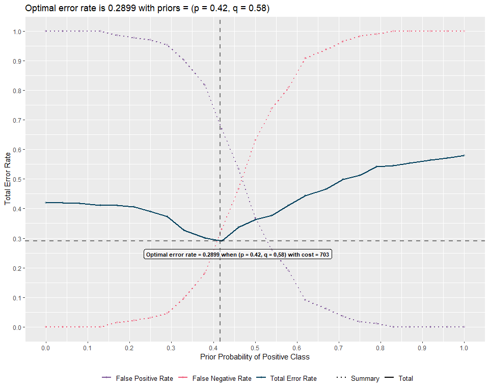

```
---------------------------
Generating plot with priors of range [0.001, 0.999]
# Searching for optimal values by minimizing total cost.
# Found optimal cost from dataset: 188.00
# Total error rate at optimal cost: 0.5449
# Optimal priors for minimized cost: (p = 0.83, q = 0.17)
# Cost calculated with penatly = 10
---------------------------
```

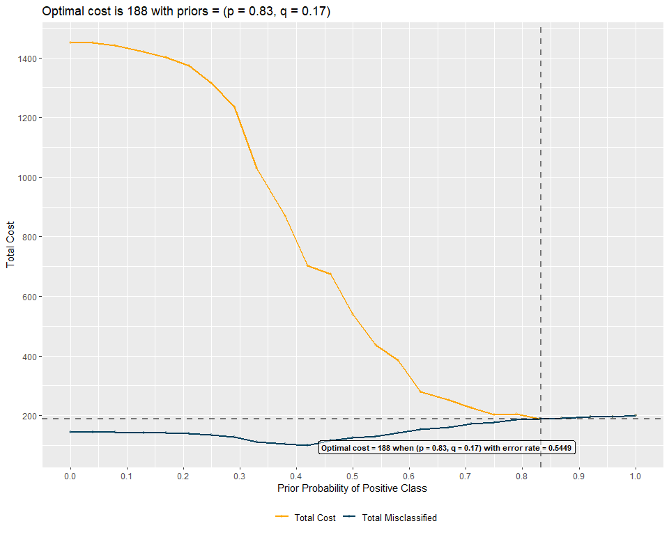

## Cross-Validation Analysis

> This section is a revision of the logistic regression CV. I was unable to complete the LDA CV analysis but I had reworked this analysis from my previous report in order to better understand how to accomplish the assignment. I hope to submit a revision before solutions are released for homework 3; the work is simply in progress.

### 10-fold CV

```
---------------------------
Performing 10-fold CV:
# Samples: 345
# Thresholds: 100
# k folds: 10 || # rounds: 100
---------------------------
tibble [100 x 4] (S3: tbl_df/tbl/data.frame)
 $ total.err : num [1:100] 0.58 0.57 0.566 0.562 0.558 ...
 $ ci.low    : num [1:100] 0.575 0.565 0.561 0.557 0.553 ...
 $ ci.high   : num [1:100] 0.585 0.575 0.571 0.568 0.563 ...
 $ thresholds: num [1:100] 0 0.0101 0.0202 0.0303 0.0404 ...
tibble [300 x 4] (S3: tbl_df/tbl/data.frame)
 $ thresholds: num [1:300] 0 0 0 0.0101 0.0101 ...
 $ category  : chr [1:300] "total.err" "ci.low" "ci.high" "total.err" ...
 $ error     : num [1:300] 0.58 0.575 0.585 0.57 0.565 ...
 $ linetype  : logi [1:300] TRUE FALSE FALSE TRUE FALSE FALSE ...
---------------------------
Calculating 10-fold CV table:
# Samples: 345
# Threshold: 1
# k folds: 10 || # rounds: 100
---------------------------
                      Length Class
results                  2   -none-
plot                     2   -none-
optimal_threshold        1   -none-
confusion_mat         4000   -none-
confusion_mat_summary    2   -none-
                      Mode
results               list
plot                  list
optimal_threshold     numeric
confusion_mat         numeric
confusion_mat_summary list
```

```
$plot

$optimal_threshold
[1] 0.5253
```

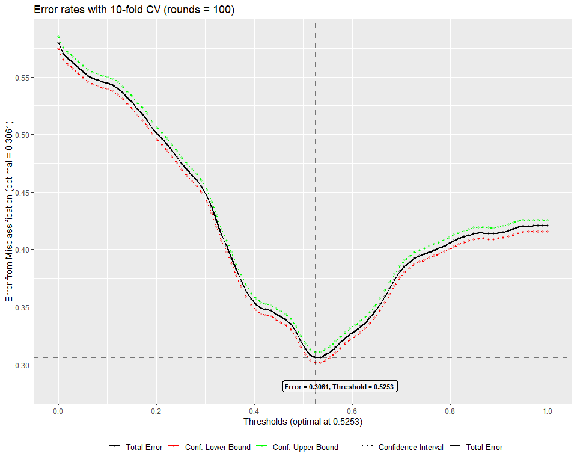

```
Optimal threshold: 0.525252525252525
$mean
       [,1]  [,2]
[1,] 167.76 73.38
[2,]  32.24 71.62

$sterr
       [,1]   [,2]
[1,] 0.2137 0.1973
[2,] 0.2137 0.1973
```

### 3-fold CV

```
---------------------------
Performing 3-fold CV:
# Samples: 345
# Thresholds: 100
# k folds: 3 || # rounds: 100
---------------------------
tibble [100 x 4] (S3: tbl_df/tbl/data.frame)
 $ total.err : num [1:100] 0.58 0.57 0.565 0.562 0.557 ...
 $ ci.low    : num [1:100] 0.575 0.565 0.561 0.557 0.552 ...
 $ ci.high   : num [1:100] 0.584 0.574 0.57 0.566 0.562 ...
 $ thresholds: num [1:100] 0 0.0101 0.0202 0.0303 0.0404 ...
tibble [300 x 4] (S3: tbl_df/tbl/data.frame)
 $ thresholds: num [1:300] 0 0 0 0.0101 0.0101 ...
 $ category  : chr [1:300] "total.err" "ci.low" "ci.high" "total.err" ...
 $ error     : num [1:300] 0.58 0.575 0.584 0.57 0.565 ...
 $ linetype  : logi [1:300] TRUE FALSE FALSE TRUE FALSE FALSE ...
---------------------------
Calculating 3-fold CV table:
# Samples: 345
# Threshold: 1
# k folds: 3 || # rounds: 100
---------------------------
                      Length Class
results                  2   -none-
plot                     2   -none-
optimal_threshold        1   -none-
confusion_mat         1200   -none-
confusion_mat_summary    2   -none-
                      Mode
results               list
plot                  list
optimal_threshold     numeric
confusion_mat         numeric
confusion_mat_summary list
```

```
$plot

$optimal_threshold
[1] 0.5152
```

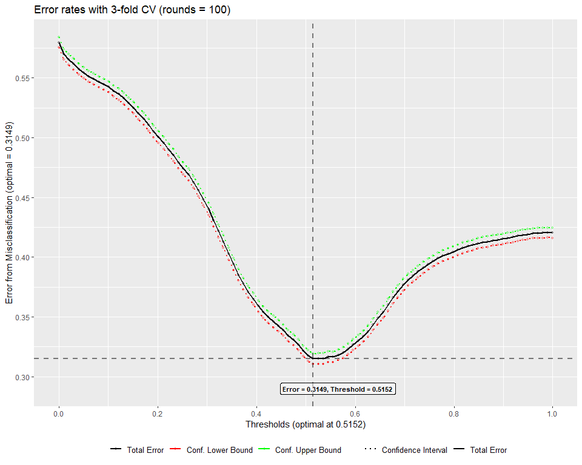

```
Optimal threshold: 0.515151515151515
$mean
       [,1]  [,2]
[1,] 161.88 71.42
[2,]  38.12 73.58

$sterr
       [,1]   [,2]
[1,] 0.3901 0.2742
[2,] 0.3901 0.2742
```

## Session Information

*This document was generated from an [R Markdown](http://rmarkdown.rstudio.com) Notebook (See the `vignettes/HW3_report.Rmd` in the project’s sub-directory). The setup chunk for this document sets the root directory to the project root directory using the `here` package; all file paths are relative to the project root.*